# The Effect of Non-Cognitive Skills on Academic Performance: Does it Vary by Socio-Economic Status?

Garen Avanesian, Ksenia Rozhkova

2023-11-11

#### Abstract

The effect of SES on academic achievement is significantly reduced with the implementation of non-cognitive skills into the analysis. The higher return to investment into non-cognitive skills will be observed for the richest. Socio-cultural context matters. Policy discussion.

### Introduction

Education plays a pivotal role in the formation of human capital and remains a key facilitator of social mobility. Being academically successful at school is strongly linked to further educational attainment, and, therefore, may compensate for disadvantaged background. However, academic performance is also the result of unequal educational opportunities. Children, whose parents (especially mother) have higher education, higher cultural capital, and better financial resources study better (Ditton et al., 2019). Since achievements build up on the earlier performance, initial academic disparities increase with the progress of the educational trajectory (Stumm, 2016). Almost one fifth of the variance in education is explained by family socio-economic status (SES) (Erikson, 2016), with the gap in future academic achievements being already formed at kindergarten entry (Reardon, Portilla, 2016). Children from higher SES-families demonstrate a steadier transition to higher education compared to their disadvantaged peers (Jackson, 2013), even when they have similar levels of skills (Gil-Hernánde, 2021).

Research concerning academic performance is usually centered on cognitive abilities. However, ignoring non-cognitive skills biases the estimates of the related returns to education (Heckman, 2000). Non-cognitive skills, also referred to as personality or socio-emotional skills in different fields of social sciences, have recently turned into a prominent instrument of educational research. There are several reasons for that. First, they are known to be linked to a wide array of adult outcomes from wages and employment to health and longevity (Heckman et al., 2006). Second, non-cognitive skills are affected by early social environment, socialization, and family, and, therefore, may serve as a transmission mechanism of inequality. For low-SES students, non-cognitive skills are especially predictive of educational attainment and may help in overcoming their disadvantaged background (Liu, 2020). Third, non-cognitive skills influence the process of human capital accumulation, supporting the development of cognitive abilities from early childhood (“skills beget skills”) (Cunha, Heckman, 2007; 2008). Evidence suggests that non-cognitive skills explain as much as 21% in literacy development at early educational stages (Hindman et al., 2010). Finally, non-cognitive skills remain responsive to external influences until late adolescence, despite early initial development (Heckman & Kautz, 2013). Therefore, certain policies, aimed at developing positive non-cognitive skills, may be useful to reduce social inequality.

### Literature Review

#### Non-cognitive skills in educational context

Unlike other socio-economic results, where non-cognitive skills were incorporated only recently (e.g., labour market outcomes), the search for the association between personality and academic performance has a long-standing history (Kline & Gale, 1971). However, little agreement exists on which non-cognitive skills should be in the focus of research and policy. The most convenient and widespread approach is relying on well-developed psychological concepts such as the Big Five (McCrae, John, 1992). In this framework, personality can be described from the perspective of five orthogonal factors: conscientiousness (task performance), openness to experience (open-mindedness), extraversion (engaging with others), neuroticism (emotional regulation), and agreeableness (collaboration). By providing a critical review, De Raad and Schouwenburg (1996) contributed to the Big Five becoming widespread in educational context.

The most influential out of five is conscientiousness (Poropat, 2009; O’Connor, Paunonen, 2007; Bratko et al. 2006). Conscientiousness is positively correlated with student effort, self-regulation, and norm following (Zamarro et al., 2019), resulting in higher attendance rates (Chamorro-Premuzic & Furnham, 2003; Conard, 2006), consistently doing homework, and behaving well in a school setting (West et al.,2015). Conscientiousness is associated with better academic results across the whole educational cycle from elementary school (Rosander & Bäckström, 2014; Richardson et al., 2012) to tertiary education (De Raad, Schouwenburg, 1996). Irrespective of social background, non-cognitive skills measured before university entry are strong predictors of academic achievement, with high levels of conscientiousness compensating for poorer cognitive skills (Edwards et al., 2022; Gil-Hernánde, 2021). In contrast, low levels of conscientiousness are shown to aggravate the negative effect of lower socio-economic background on academic achievement, at least in university students (Edwards et al., 2022).

Neuroticism, or lack of emotional stability, has as well proved to predict performance and to limit academic success (Chamorro-Premuzic, Furnham, 2003). The relationship appears to be nonlinear: while emotionally stable students are more likely to employ effective learning styles (Komarraju et al., 2011), they also spend less time on homework (Lubbers et al., 2010). Therefore, the effect of neuroticism on academic performance may vary, depending not only on the level of education, but rather on the level of manifestation of the trait. Neuroticism is characterized by anxiety, which may lead to worse performance under pressure (e.g., in exam setting). Neuroticism and conscientiousness together predict exam marks above academic variables, accounting for 10 percent of the variance (Chamorro-Premuzic, Furnham, 2003).

Mixed results exist for openness. Openness to experience is positively related to intelligence, stronger than any other personality trait (Borghans et al., 2008), especially at higher stages of education (Poropat, 2014). However, its correlation with achievements is more pronounced for high-ability adolescents (Heaven, Ciarrochi, 2012). On one hand, openness increases the probability of higher education enrollment for adolescents with disadvantaged backgrounds (Lundberg, 2013) and may be associated with deeper knowledge of subjects. On the other hand, Individuals low in openness may be more practical in choosing their learning strategies, leading to better academic results (Chamorro-Premuzic & Furnham, 2003). The remaining Big Five categories (extraversion and agreeableness) usually show little to no association, except for primary education (Poropat, 2014).

Noncognitive skills remain significantly correlated with grades among elementary and lower-secondary school children, even after including cognitive abilities and SES into the analysis (Boman, 2022). However, limited studies exist for countries other than the US and EU, including Russia. A positive correlation with conscientiousness and openness among high school students (Mishkevich, 2021), however, only 135 respondents were present in the sample. Similarly, on a sample of 176 respondents, introversion, agreeableness, neuroticism, and openness appear to be significant contributors to academic achievement of university students in Russia (Nye et al., 2013).

Different Big Five categories may be linked to different subjects (Rosander et al., 2011). Evidence suggests that personality traits may be more relevant for the explanation of mathematics grades and the overall GPA rather than languages (Vitulić, Zupančič, 2012). Conscientiousness is more important for Math and Science scores (Heaven, Ciarrochi, 2012). Self-efficacy and education aspirations, which are also correlated with conscientiousness, predict academic performance in mathematics, based on data from PISA and TIMSS (Lee, Stankov, 2018). Openness appears to be the only Big Five category, significantly associated with verbal SAT score (Noftle, Robins, 2007).

A problem, arising with the measurement of personality traits in a survey setting, is reference bias which is a tendency to respond to questionnaires in a socially acceptable way. For instance, being more conscientious (hard-working, aim-oriented etc.) and emotionally stable is more socially acceptable. Therefore, item response for some of the Big Five categories, including conscientiousness and neuroticism, may be unlikely to capture extremes (Morris et al., 2021). Self-reports overstate at the bottom and top of the distribution of non-cognitive skills (Edwards et al., 2022). Other-rated traits (e.g., parents, teachers, peers) may show more valid and consistent results (Poropat, 2014, Feng et al., 2022). Another issue is possible reversed causality. For example, schooling intensity decreases emotional stability (Dahmann, Anger, 2018; Korthals et al., 2022) but increases openness for students with lower SES (Dahmann, Anger, 2018). Therefore, methodological approaches should address the issue of causality.

#### Non-cognitive skills and SES

Differences in non-cognitive skills associated with SES are well documented (Attanasio, Blundell, Conti & Mason, 2020; Elkins & Schurer 2020; Heckman & Mosso 2014) and tend to accumulate over time (Fletcher, Wolfe, 2016). One of the reasons is the difference in children’s upbringing, associated with parental SES (Reardon & Portilla, 2016). Orel and colleagues (2018) showed that the development of both cognitive and non-cognitive skills among Russian first-graders is associated with such family characteristics as mother’s education, parental involvement, and number of books at home.

Non-cognitive measures are more predictive of academic achievements for low-SES students (Liu, 2020). Although low-SES individuals demonstrate substantially lower levels of non-cognitive skills measured by the Big Five, they enjoy higher returns to skills (Shanahan et al., 2014). Moreover, socio-economic status is more related to non-cognitive skills, not cognitive abilities (Marks, 2016). In Russia, developing growth mindset, self-efficacy, and grit as measures of non-cognitive skills is positively associated with academic achievement, especially for children coming from low-SES families (Avanesian et al., 2022).

### **Methodology**

Despite substantial coverage of schools in each participating city and a balanced sample that aimed to recruit approximately equal numbers of students from both age cohorts and by sex, the data suffers from missingness and non-response in some key variables of the study. In addition to five non-cognitive skills, these variables referred to academic performance in reading/language and mathematics, index of socio-economic status (a composite indicator produced by the OECD based on education and occupation of both parents, as well as household possessions), and migration background. Sample summary after dropping all missing values are presented in Table 1.

City

1. Younger
2. Older

Female

Male

N_Schools

Total_Obs

Bogota

2,709

2,833

2,812

2,730

145

5,542

Daegu

1,555

3,184

2,381

2,358

104

4,739

Helsinki

715

1,477

1,114

1,078

65

2,192

Houston

3,053

2,929

3,115

2,867

102

5,982

Istanbul

2,591

2,996

3,059

2,528

101

5,587

Manizales

3,135

3,412

3,360

3,187

85

6,547

Moscow

3,244

3,372

3,231

3,385

78

6,616

Suzhou

3,591

3,598

3,391

3,798

122

7,189

Total

20,593

23,801

22,463

21,931

802

44,394

Source: Calculations of the authors based on the OECD SSES 2019 data.

The primary purpose of the study referred to the estimation of the effect that non-cognitive skills have on academic performance. Grades in reading and language, as well as in mathematics, served as dependent variables of the analysis. Since the grades were fixed on the ordinal scale and grading system differs from country to country, for the plausibility of interpretation we binarized these variables, with 1 referring to the schoolchildren that represent top 25% performers in each subject, and 0 if otherwise. This approach enabled interpretation of the estimated effects of non-cognitive skills on high academic performance on the probability scale, with calculated coefficients representing a probability change of high performance due to the increase of a skill on 1 standard deviation.

As the students were nested within schools, and the data were collected by cities, the verification model needed to account for the hierarchical nature of the data. Furthermore, a number of unobserved city and school factors beyond the scope of this study affect academic performance, which implies that students enrolled in the same schools within respective cities are not independent from each other in terms of their grades, and, as a consequence, variance in the outcome variables is non-random. In addition to that, we wanted to estimate the degree to which the effect of non-cognitive skills on high academic performance varies across SES quintiles, implying that children from the poorest families could substantially differ in both non-cognitive skills and their chances to demonstrate high academic performance from the richest ones.

### Results

#### Socio-Economic Disparity in Academic Performance

The polarization of academic performance along socio-economic lines presents a multifaceted view of educational outcomes. Table 2 delineates the proportion of students achieving high academic performance in core subjects such as reading, language, and mathematics, contrasting the bottom 40% against the top 10% of students classified by family socio-economic status (SES).

A critical measure, namely, the Wealth Parity Ratio (WPR), indicates equity or learning outcomes. A WPR value approaching 1 suggests a balanced distribution across socio-economic strata, implying that students from the lowest and highest SES backgrounds are equally represented. For high achievement, WPR values significantly below 1 highlight a disparity to the detriment of students from less affluent backgrounds. Whereas for low achievement the values above 1 show concentration of poor academic performance amongst the schoolchildren with the economically disadvantaged background.

These findings underscore the persistent influence of socio-economic status on educational achievement. Cities exhibit diverse profiles of academic excellence and struggle, with wealth-based disparities manifesting in both the highest and lowest echelons of performance. The WPR, in this context, serves as a stark reminder of the pervasive inequities that characterize educational systems and the importance of socio-economic considerations in crafting policy interventions aimed at redressing these imbalances. Overall, the table highlights the importance of considering equity and wealth inequality in education, as different cities have varying levels of outstanding students across wealth levels, as well as different levels of those substantially falling behind in their academic achievement due to the socio-economic status.

| City | LP_Bottom 40% | LP_Top 10% | WPR_LP | HP_Bottom 40% | HP_Top 10% | WPR_HP |
| --- | --- | --- | --- | --- | --- | --- |
| Bogota | 0.223 | 0.131 | 1.702 | 0.114 | 0.219 | 0.521 |
| Daegu | 0.181 | 0.124 | 1.460 | 0.130 | 0.268 | 0.485 |
| Helsinki | 0.186 | 0.045 | 4.133 | 0.083 | 0.327 | 0.254 |
| Houston | 0.145 | 0.082 | 1.768 | 0.083 | 0.322 | 0.258 |
| Istanbul | 0.157 | 0.028 | 5.607 | 0.184 | 0.564 | 0.326 |
| Manizales | 0.167 | 0.052 | 3.212 | 0.092 | 0.349 | 0.264 |
| Moscow | 0.186 | 0.075 | 2.480 | 0.087 | 0.161 | 0.540 |
| Suzhou | 0.174 | 0.080 | 2.175 | 0.138 | 0.336 | 0.411 |

Source: Calculations of the authors based on OECD SSES 2019 data.

#### Can Non-Cognitive Skills Increase the Equity for the Poorest?

The pursuit of educational equity remains a paramount challenge in the face of persistent socio-economic disparities. Recognizing the potential of non-cognitive skills (NCS) to bridge the performance gap, this analysis probes deeper into the influence of these skills on academic outcomes. To examine whether NCS can attenuate the socio-economic inequities in academic performance, we juxtapose two multilevel regression models:

1. **Base Model**: Grades: Bottom 25% ~ Sex + SES Group + Migration Background + (1|City/School ID) + (1| Age Cohort) + (1 + SES Group|City)
2. **Enhanced Model with NCS**: Grades: Bottom 25% ~ Sex + SES Group + Migration Background + Open Mindedness + Task Performance + Engaging with Others + Collaboration + Emotional Regulation + (1|City/School ID) + (1| Age Cohort) + (1 + SES Group|City)

Similar models were performed for high achievement as a dependent variable. The outputs of all 4 regression models are summarized in Table 3. In this section, our interpretation will focus on the model on low achievement as it is critical to make sure that schoolchildren from the economically adverse cohorts are not showing the worst grades.

| **Characteristic** | Low Performance: Model without NCS **Beta** | Low Performance: Model without NCS **95% CI**<sup>1</sup> | Low Performance: Model without NCS **p-value** | Low Performance: Model with NCS **Beta** | Low Performance: Model with NCS **95% CI**<sup>1</sup> | Low Performance: Model with NCS **p-value** | High Performance: Model without NCS **Beta** | High Performance: Model without NCS **95% CI**<sup>1</sup> | High Performance: Model without NCS **p-value** | High Performance: Model with NCS **Beta** | High Performance: Model with NCS **95% CI**<sup>1</sup> | High Performance: Model with NCS **p-value** |
| --- | --- | --- | --- | --- | --- | --- | --- | --- | --- | --- | --- | --- |
| (Intercept) | 0.06 | -0.03, 0.15 | 0.10 | 0.07 | 0.00, 0.14 | 0.043 | 0.28 | -0.05, 0.61 | 0.094 | 0.27 | -0.41, 0.94 | 0.4 |
| Sex |  |  |  |  |  |  |  |  |  |  |  |  |
| Female | — | — |  | — | — |  | — | — |  | — | — |  |
| Male | 0.06 | 0.05, 0.07 | <0.001 | 0.06 | 0.05, 0.06 | <0.001 | -0.05 | -0.05, -0.04 | <0.001 | -0.04 | -0.05, -0.04 | <0.001 |
| SES Group |  |  |  |  |  |  |  |  |  |  |  |  |
| Top 10% | — | — |  | — | — |  | — | — |  | — | — |  |
| Bottom 40% | 0.07 | -0.16, 0.30 | 0.5 | 0.06 | 0.02, 0.09 | 0.004 | -0.12 | -0.45, 0.20 | 0.3 | -0.11 | -0.22, 0.01 | 0.063 |
| Middle 50% | 0.02 | -0.14, 0.18 | 0.7 | 0.01 | -0.01, 0.03 | 0.2 | -0.08 | -0.37, 0.22 | 0.5 | -0.07 | -0.17, 0.04 | 0.2 |
| Migration Background |  |  |  |  |  |  |  |  |  |  |  |  |
| 0 | — | — |  | — | — |  | — | — |  | — | — |  |
| 1 | 0.01 | 0.00, 0.02 | 0.025 | 0.01 | 0.00, 0.02 | 0.020 | 0.00 | -0.01, 0.01 | 0.9 | 0.00 | -0.01, 0.01 | >0.9 |
| No. Obs. | 44,394 |  |  | 44,394 |  |  | 44,394 |  |  | 44,394 |  |  |
| Open Mindedness |  |  |  | -0.02 | -0.03, -0.02 | <0.001 |  |  |  | 0.03 | 0.02, 0.03 | <0.001 |
| Task Performance |  |  |  | -0.02 | -0.03, -0.02 | <0.001 |  |  |  | 0.04 | 0.04, 0.05 | <0.001 |
| Engaging with Others |  |  |  | 0.00 | -0.01, 0.00 | 0.3 |  |  |  | 0.01 | 0.00, 0.01 | 0.020 |
| Collaboration |  |  |  | 0.01 | 0.01, 0.02 | <0.001 |  |  |  | -0.02 | -0.02, -0.01 | <0.001 |
| Emotional Regulation |  |  |  | 0.01 | 0.00, 0.01 | 0.005 |  |  |  | -0.01 | -0.02, -0.01 | <0.001 |

<sup>1</sup> CI = Confidence Interval

Source: Calculations of the authors based on the OECD SSES 2019 data.

This foundational model appraises the effect of socio-economic status and demographic factors on the likelihood of students falling into the bottom 25% of academic performers without considering the influence of non-cognitive skills. In contrast, this model integrates non-cognitive skills into the equation, offering a more nuanced view by incorporating traits such as open-mindedness, task performance, engagement with others, collaboration, and emotional regulation.

The comparative analysis delineated in Figure 1 reflects the disparity in the probability of low academic performance between students from economically disadvantaged backgrounds (the bottom 40% by SES) and their more affluent peers. By integrating NCS into the modeling framework, we aim to discern whether these skills can serve as a buffer against the adverse effects of low SES on academic achievement.

In examining the effects of non-cognitive skills on academic performance, two nested multilevel models were compared using a likelihood ratio test. The base model, which included only socio-demographic controls (Model 1), was compared to an extended model incorporating non-cognitive skill measures (Model 2). The test revealed a significant difference between the models ($\chi^2(5) = 478.67, p < .001$), indicating that the inclusion of non-cognitive skills significantly improved the fit of the model to the data. This result suggests that non-cognitive skills contribute meaningfully to the explanation of academic performance variations among students. This finding suggests that non-cognitive skills play a significant role in academic achievement, beyond the effects of socio-economic status alone.

The observed trends across the diverse cityscape further underscore the complex interplay between SES and academic performance. The findings emphasize that almost all cities exhibit a reduction in SES effect size with the inclusion of non-cognitive skills; however, this reduction is not uniform. In the case of Manizales, the change is modest (less than 0.5 percentage points), indicating that while non-cognitive skills play a role in academic outcomes, they do not fully counterbalance the effects of socio-economic disparities. Interpretations suggest that policies promoting the development of non-cognitive skills could be an effective tool for enhancing educational equity, providing children from lower SES backgrounds with a stronger foundation to succeed academically.

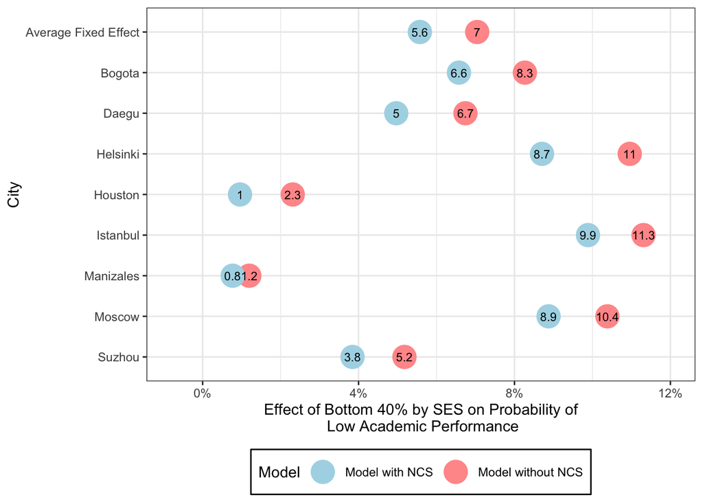

Source: Calculations of the authors based on the OECD SSES 2019 data.

Note: the effect of bottom 40% by SES is calculated with repsect to top 10% as a reference.

#### What Does Variance in Academic Perofrmance Tell Us?

Our analysis utilized two additional multilevel linear regression models to explore the determinants of academic performance, distinguishing between students with low and high achievement. The models incorporated a range of predictor variables, including sex, migration background, and several non-cognitive skills (open-mindedness, task performance, engaging with others, collaboration, emotional regulation). Each model accounted for the nested structure of the data, allowing for random intercepts by city and school ID, and for random slopes by the interaction between city and socio-economic status group for all non-cognitive skill variables.

When examining the random slopes associated with the interaction of city and socio-economic status group on non-cognitive skills, we observed variability in the impact of these skills on academic outcomes. First of all, all five non-cognitive skills account for 0.5% of variance in the model on high achievement, with contribution of these factors being almost non-visible for variartion in low achievement. These finding suggests that policy interventions targeted toward improvement of academic achievement would be more sensitive to the upper tails of academic performance distribution, producing there more profound returns. In other words, the contribution of non-cognitive skills to academic performance variance is more substantial among high performers. These implications particularly refer to Engaging with Others and Collaboration, indicating that these skills may play a pivotal role in distinguishing high achievers within varied city and SES contexts. Notably, the additional variance component due to the random slope of the intercept across cities and SES groups was significant in both models, but markedly higher among high performers (2.7%) compared to low performers (0.7%), pointing to a greater heterogeneity in the baseline achievement levels across different SES groups within cities for the high achievers.

The residual variance, representing within-student variability not explained by the models, was relatively stable across both levels of achievement (70% for low performers and 79% for high performers), underscoring a consistent level of individual differences in academic performance irrespective of the achievement stratification.

Overall, our models reveal that while individual student differences account for the majority of the variance in academic performance, there is a non-trivial proportion of variance explained by non-cognitive skills, particularly among high achievers. This underlines the potential of targeted interventions aimed at developing these skills to foster academic excellence, especially within socio-economically diverse urban environments.

| Effect | Group | Term | Low Performance | High Performance | Explained Variance: Low Performance | Explained Variance: Hight Performance |
| --- | --- | --- | --- | --- | --- | --- |
| Random Intercept | SchID/City | sd (Intercept) | 0.122 | 0.148 | 10.042 | 16.481 |
| Random Slope | City * SES Group | sd Emotional_Regulation | 0.008 | 0.009 | 0.043 | 0.061 |
| Random Slope | City * SES Group | sd Collaboration | 0.009 | 0.013 | 0.055 | 0.127 |
| Random Slope | City * SES Group | sd Engaging_with_Others | 0.008 | 0.014 | 0.043 | 0.147 |
| Random Slope | City * SES Group | sd Task_Performance | 0.011 | 0.012 | 0.082 | 0.108 |
| Random Slope | City * SES Group | sd Open_Mindedness | 0.012 | 0.007 | 0.097 | 0.037 |
| Random Slope | City * SES Group | sd (Intercept) | 0.033 | 0.060 | 0.735 | 2.709 |
| Random Intercept | City | sd (Intercept) | 0.014 | 0.005 | 0.132 | 0.019 |
| Random Intercept | Cohort | sd (Intercept) | 0.167 | 0.042 | 18.816 | 1.327 |
| Random | Residual | sd Observation | 0.322 | 0.324 | 69.955 | 78.984 |

Source: Calculations of the authors based on the OECD SSES 2019 data.

#### How Strong Are the Effects of Non-Cognitive Skills on Academic Performance?

Finally, when it comes to the non-cognitive skills, open mindedness and task performance positively affect achievement, with their the robust and statistically significant effect in both reducing low performance and accelerating high performance. As such, increase in task performance on 1 standard deviation would result in increasing the probability of hight achievement by 4%, and reducing the probability of low achievement by 2%. Open Mindedness another critical skill for academic performance, with one increase in its standard deviation resulting in the increased likelihood of high achievement and decreased likelihood of low achievement (with effect size for both models accounting for 3%).

| **Characteristic** | **Low Performance** **Beta** | **Low Performance** **95% CI**<sup>1</sup> | **Low Performance** **p-value** | **High Performance** **Beta** | **High Performance** **95% CI**<sup>1</sup> | **High Performance** **p-value** |
| --- | --- | --- | --- | --- | --- | --- |
| (Intercept) | 0.09 | -0.14, 0.33 | 0.4 | 0.20 | 0.09, 0.32 | 0.015 |
| Sex |  |  |  |  |  |  |
| Female | — | — |  | — | — |  |
| Male | 0.06 | 0.05, 0.06 | <0.001 | -0.04 | -0.05, -0.04 | <0.001 |
| Migration Background |  |  |  |  |  |  |
| 0 | — | — |  | — | — |  |
| 1 | 0.01 | 0.00, 0.02 | 0.014 | 0.00 | -0.01, 0.01 | 0.8 |
| Open Mindedness | -0.03 | -0.03, -0.02 | <0.001 | 0.03 | 0.02, 0.03 | <0.001 |
| Task Performance | -0.02 | -0.03, -0.02 | <0.001 | 0.04 | 0.04, 0.05 | <0.001 |
| Engaging with Others | 0.00 | -0.01, 0.00 | 0.5 | 0.01 | 0.00, 0.01 | 0.11 |
| Collaboration | 0.01 | 0.01, 0.02 | <0.001 | -0.02 | -0.03, -0.01 | <0.001 |
| Emotional Regulation | 0.01 | 0.00, 0.01 | 0.025 | -0.01 | -0.02, -0.01 | <0.001 |
| No. Obs. | 44,394 |  |  | 44,394 |  |  |

<sup>1</sup> CI = Confidence Interval

Source: Calculations of the authors based on the OECD SSES 2019 data.

##### Effect of Non-Cognitive Skills on the Academic Achievement of the Poorest and Its Robustness Across Socio-Economic Contexts

The substantial dataset of 44,394 individual observations lends robustness to these insights, suggesting the findings may be generalizable across similar urban educational settings. Future research could further elucidate the mechanisms at play, potentially guiding the design of targeted interventions that consider the rich tapestry of individual and environmental factors influencing student achievement.

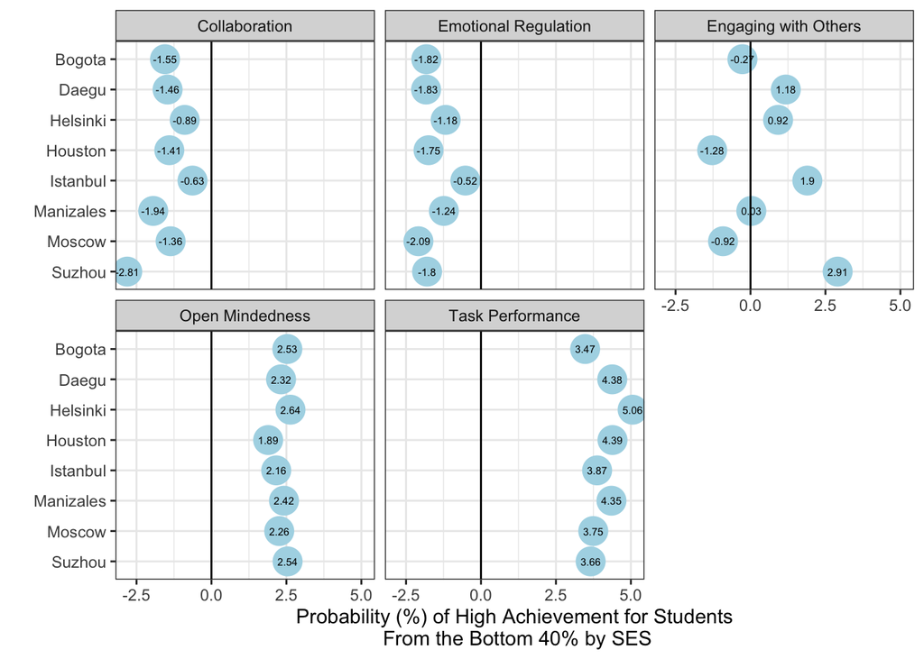

Figure. Predicted Probability of Effect of Non-Cognitive Skills on High Academic Achievement of Students from the Bottom 40% by SES

Source: Calculations of the authors based on the OECD SSES 2019 data.

Note: the effect of bottom 40% by SES is calculated with repsect to top 10% as a reference.

#### How Equitable Are Returns to Non-Cognitive Skills?

While the previous analysis indeed affirms that investing into development of non-cognitive skills, especially task performance and open mindedness, produces substantial returns on academic performance and can be used as a means to facilitate human capital gains of the students from economically adverse backgrounds, it is still unclear which socio-economic group would benefit the most from these investments. In order to adderess these issues, we visually explore the regression model on high performance, plotting the predcited probabilities of the skills with the most profound and positive effect. The provided charts illustrate the predicted probabilities of high academic achievement for students across three socio-economic status (SES) groups (Bottom 40%, Middle 50%, and Top 10%) as a function of two non-cognitive skills (NCS): Task Performance and Open Mindedness. The slopes represent the relationship between each NCS and high achievement within each SES group, disaggregated by city.

Collectively, these findings suggest that while both task performance and open-mindedness are valuable for academic achievement, the returns on these skills are not equitably distributed across SES groups. In most cases, students from the top echelons of the SES distribution reap the greatest benefits, which could exacerbate existing inequalities. This effect is less pronounced for students from lower SES groups, raising concerns about the effectiveness of NCS development initiatives for these students and pointing towards a need for tailored approaches that address the specific challenges and barriers faced by lower SES groups.

The charts underscore the importance of considering SES in educational strategies aimed at NCS development. While fostering task performance and open-mindedness can be universally beneficial, policies and interventions may need to be specifically designed to ensure that students from lower SES backgrounds are not left behind and can equally benefit from the development of these skills.

In conclusion, the visualized data call for a nuanced approach to NCS enhancement in education, one that not only recognizes the inherent value of these skills but also actively works to ensure that their benefits are accessible to all students, regardless of socio-economic standing. Further research is needed to explore the mechanisms behind the observed disparities and to identify strategies that can promote equity in the returns of non-cognitive skill development.

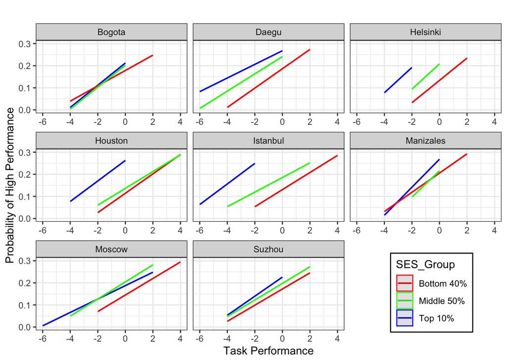

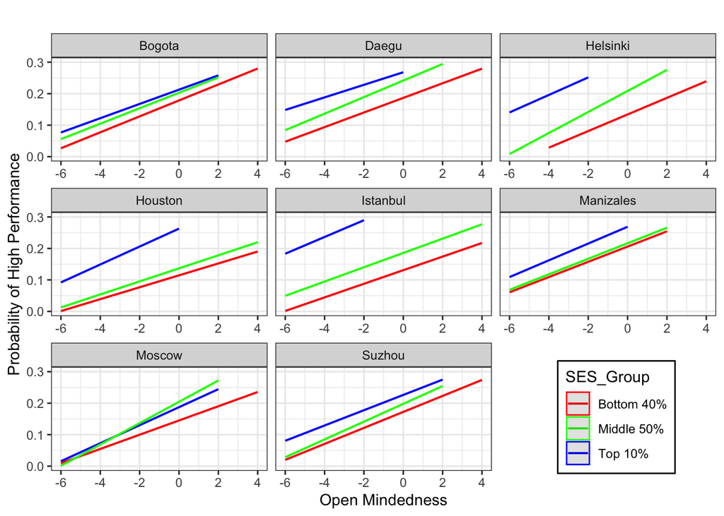

#### Non-Linearity of Emotional Regulation and Collaboration

At the final stage of our analysis, we are coming back to the effects of emotional regulation and collaboration. We are testing the hypothesis that these skills could present a nonlinear relationship with academic performance and carry out an additional regression model that adopts quadratic terms for these two variables. While the results for emotional stability do not change, patterns identified in the relationship of collaboration and academic achievement across SES groups and cities present a compelling case.

The non-linear trends are particularly interesting when analyzed across SES groups: for the Top 10% SES group, the benefits of collaboration are more pronounced at moderate levels but decline after a certain threshold. This could indicate that among students from higher SES backgrounds, there is an optimal balance of collaboration that aids performance, beyond which additional collaboration may not contribute to or may even hinder high achievement.

For the Bottom 40% SES group, the increase in high performance probability is less steep, and the decline starts at lower levels of collaboration compared to the other SES groups. This could suggest that students from lower SES backgrounds may have a narrower range of beneficial collaboration or that other factors, such as access to resources or support systems, may limit the positive effects of collaboration on their academic outcomes.

The observed patterns raise critical questions about the role of collaboration in academic success and its potential interaction with students’ socio-economic backgrounds. While previous models suggested a straightforward negative effect of emotional regulation on high achievement, the intricate non-linear relationship revealed for collaboration indicates that the impact of such non-cognitive skills on academic performance is multifaceted and contingent upon the level of skill exhibited.

The results underscore the importance of a nuanced approach to fostering collaboration skills among students. Educational strategies and interventions designed to enhance collaboration must consider the appropriate intensity and context to ensure that they are effectively supporting academic success. Additionally, the variation in effects across SES groups and cities calls for targeted measures that address the unique needs and circumstances of different student populations.

Given the complexity of these relationships, further research is warranted to explore the underlying mechanisms driving the non-linear effects of collaboration and to determine how educational policies can be tailored to harness the benefits of collaboration for all students, particularly those from lower SES backgrounds.

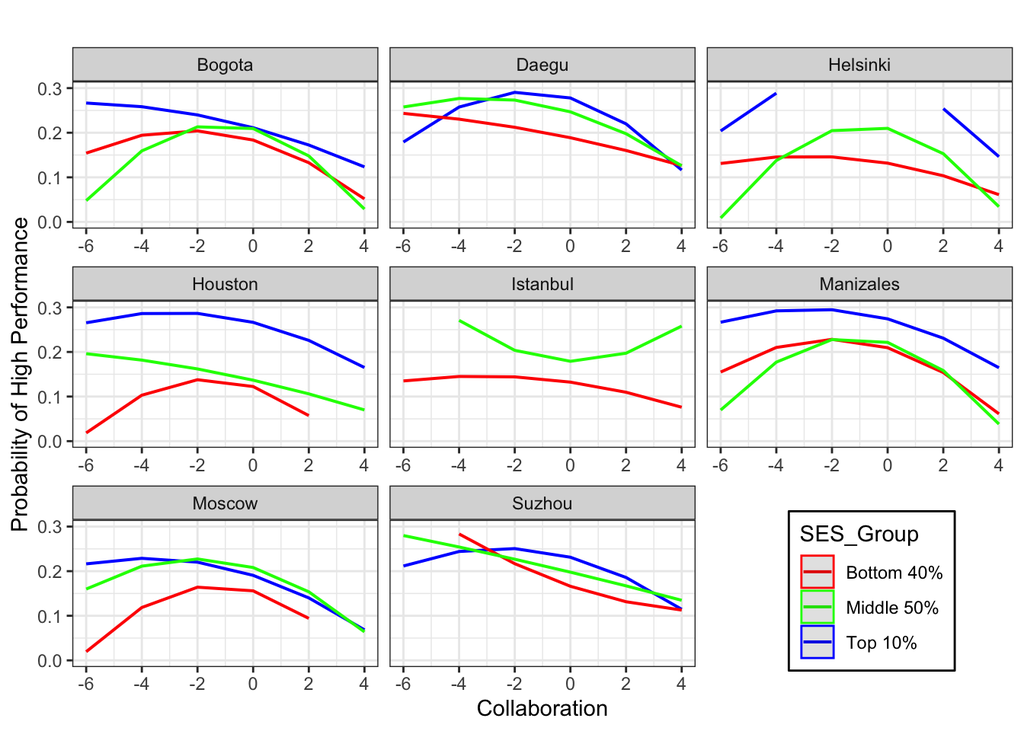

### Conclusions

The key conclusion here is however the following: the investments into non-cognitive skills would affect more the upper tail of distribution in academic performance, ie, high achievement.